# R ggplot2 作图进阶

Chris Qi

2018

钻石恒久远，一颗永流传

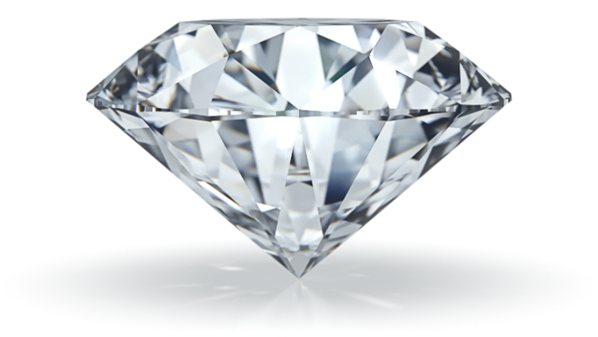

Explore the diamonds data frame with str()

- 使用 `geom_point()` 添加散点
- 使用 `geom_smooth()` 添加拟合曲线

只要平滑曲线图：

按钻石透明度（类型）来绘制平滑曲线：

进一步理解ggplot的语法，作出精致的图

- 先画一个底图，命名为dia_plot
- 用 geom_point()加一层点
  - 以颜色区分不同透明度的钻石
  - 修改点的透明度，以展现数据点的密度分布

继续探索：

- 添加拟合曲线geom_smooth()，关闭置信区间

`position = "jitter"`的用法：

小试牛刀，用`mtcars`数据做几个图，底图长这个样子： `ggplot(mtcars, aes(x = wt, y = mpg, col = cyl))`。 作图要求如下：

- Plot 1: add geom_point() to this command to create a scatter plot
- Plot 2: include the lines of the linear models, per cyl
- Plot 3: include a lm for the entire dataset in its whole

小试牛刀：

使用`airquality`，来探索`ggplot()`的散点图玩法儿：

- 先传入数据集，然后是美学相关的层
- 再加几何客体层中的散点 `geom_point()`
- 进一步修饰散点，颜色color=“steelblue”, 透明度`alpha=0.4`, 大小`size=3`
- 每个月用不同的颜色来表示

添加统计信息层中的拟合曲线： `stat_smooth()`与`geom_smooth()`等效：

可以没有点层，只留曲线：

将曲线规定为直线(线性回归)：

去掉置信区间：

给每个月份拟合一条回归线：

基于整体数据进行拟合，group=1

颜色还是在起作用，在点层

group 在统计层，允许我们继续添加统计层，并且按每个月拟合

玩转调色板：

- 加载颜色包 `library(RColorBrewer)`
- 从Dark2中选5个颜色，外加黑色赋值为`myColors`
- 看一看dark2是哪5种颜色 `display.brewer.pal(5,"Dark2")`

（在自己电脑上记得安装`RColorBrewer`这个包）

复制前一幅图的代码，添加`scale_color_manual("Month", values=myColors)`

不同月份画在不同面板上，`facet_grid(.~Month)`

改变与数据无关的主题背景:

继续颜色的故事： 下面的图，默认颜色太跳跃鲜艳

（在自己电脑上记得安装`car`这个包）

我只想要一种颜色的渐变色，怎么破？

`scale_fill_brewer`来帮忙： （在自己电脑上记得安装`colorRampPalette`这个包）

`scale_fill_brewer`虽好，可是默认只有就种颜色，而我们的`vocabulary`这个变量有11类！ 又该如何是好？ `colorRampPalette` 来救场，借鸡生蛋，变出更多的颜色：

案例分析： 泰坦尼克生还者数据 （若在自己本地硬盘上操作，请下载数据(https://www.dropbox.com/s/8ow74rzp6rka8q9/titanic.csv?dl=1)）

看一看有多少幸存者，有多少遇难者？

男女分布, 看着该船上性别比例？

船舱分布，看一看每一个等级的船舱分别有多少人

看一看，不同性别的乘客在不同船舱的分布是否平均？

生还者特征描述 谁更容易生还，男士，女士？

谁更容易生还，头等舱的？

综合上面的信息，是不是头等舱的女士更容易生还？我们来验证一下：